# Project8

# Q-9

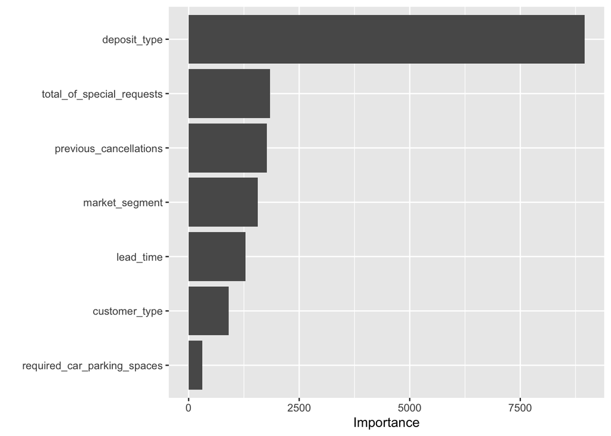

```r
vip(m1)
```

# Q-10, Q-11

Build a naive bayes model using the training set. The outcome variable is “is_cancelled”. Create the naive bayes model with default setttings and do not appy laplace correction. Use all the remaining columns as input data. Save this into m2. What is the prior probability of a reservation being Cancelled?

```r
m2 <- naiveBayes(is_cancelled ~ ., data = house_train)
# Calculate prior probability of 'Cancelled'
m2
```

```
##
## Naive Bayes Classifier for Discrete Predictors
##
## Call:
## naiveBayes.default(x = X, y = Y, laplace = laplace)
##
## A-priori probabilities:
## Y
##    Cancelled NotCancelled
##    0.3704187    0.6295813
##
## Conditional probabilities:
##               deposit_type
## Y                No Deposit   Non Refund   Refundable
##   Cancelled    0.6736763898 0.3254191298 0.0009044804
##   NotCancelled 0.9968830774 0.0013684050 0.0017485176
##
##               lead_time
## Y                     <15      >=100       >=15
##   Cancelled    0.07733307 0.55318668 0.36948025
##   NotCancelled 0.30925954 0.31066596 0.38007450
##
##               previous_cancellations
## Y                       >=3            0            1            2
##   Cancelled    0.0039086475 0.8672675001 0.1279516749 0.0008721775
##   NotCancelled 0.0017105063 0.9929869241 0.0043332827 0.0009692869
##
##               market_segment
## Y                  Aviation Complementary    Corporate       Direct
##   Cancelled    1.162903e-03  2.196595e-03 2.264431e-02 4.490099e-02
##   NotCancelled 2.603771e-03  8.609548e-03 5.745401e-02 1.411548e-01
##               market_segment
## Y                    Groups Offline TA/TO    Online TA    Undefined
##   Cancelled    2.717318e-01  1.874536e-01 4.698776e-01 3.230287e-05
##   NotCancelled 1.037897e-01  2.117227e-01 4.746655e-01 0.000000e+00
##
##               total_of_special_requests
## Y                     >=3          0          1          2
##   Cancelled    0.01082146 0.75734083 0.16813645 0.06370126
##   NotCancelled 0.03101718 0.48988901 0.34550327 0.13359054
##
##               required_car_parking_spaces
## Y                       >=3            0            1            2
##   Cancelled    0.000000e+00 1.000000e+00 0.000000e+00 0.000000e+00
##   NotCancelled 1.900563e-05 9.014748e-01 9.812605e-02 3.801125e-04
##
##               customer_type
## Y                 Contract       Group   Transient Transient-Party
##   Cancelled    0.028458830 0.001421326 0.824886132     0.145233711
##   NotCancelled 0.037669150 0.006575946 0.705906948     0.249847955
```

```r
#10 ans: prior probabilities: Cancelled : 0.3704187
#11 ans: p(lead_time >=100 | is_cancelled=Cancelled) = 0.55318668
```

# Q-12

Using m2 make predictions on the testing set. What is the testing accuracy expressed in percentage? Use the predict() function, and set type=‘class’.

```r
# predicted classes
pred1=predict(m2, newdata=house_test, type='class')

cm2 = caret::confusionMatrix(reference=house_test$is_cancelled, data=pred1, mode = "everything", positive = "Cancelled")
cm2$overall[["Accuracy"]]
```

```
## [1] 0.7687411
```

```r
# Ans: Accuracy: 0.7687
```

# Q-13, Q-14

```r
cm2
```

```
## Confusion Matrix and Statistics
##
##               Reference
## Prediction     Cancelled NotCancelled
##   Cancelled         6904         1920
##   NotCancelled      6363        20630
##
##                Accuracy : 0.7687
##                  95% CI : (0.7643, 0.7731)
##     No Information Rate : 0.6296
##     P-Value [Acc > NIR] : < 2.2e-16
##
##                   Kappa : 0.4675
##
##  Mcnemar's Test P-Value : < 2.2e-16
##
##             Sensitivity : 0.5204
##             Specificity : 0.9149
##          Pos Pred Value : 0.7824
##          Neg Pred Value : 0.7643
##               Precision : 0.7824
##                  Recall : 0.5204
##                      F1 : 0.6251
##              Prevalence : 0.3704
##          Detection Rate : 0.1928
##    Detection Prevalence : 0.2464
##       Balanced Accuracy : 0.7176
##
##        'Positive' Class : Cancelled
##
```

```r
#13 Ans: False Positives: 1920
#14 Ans: Specificity : 0.9149
```